# Polynomial Regression

This webpage shows some of the results retrieved by [this Jupyter Notebook](https://github.com/readmees/erudite2020/blob/master/Polynomial%20Regression%20and%20Random%20Forest/polynomial_fit_html.ipynb).

# Data visualization

Lets show how the features change with time, see the data/DataReadMe.pdf for more information about those features.

First of all a demonstration of the visualization of a single team/dataset, by default the Croperators. Since a lot of datapoint are the same for the teams, it's not always clear if there's only one datapoint measured or multiple. If you look closer, the points where multiple datapoints are measured are bigger points. This is not that userfriendly, which is why the regression line is added (which of course takes all datapoints into account).

```
Please type Yes or No (case sensitive)
Is the Croperators dataset still part of your datasets?.
            [Yes/No]Yes
```

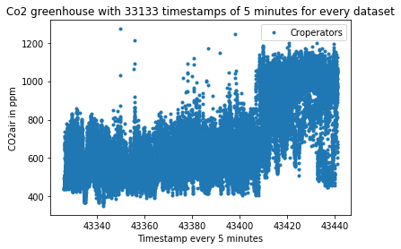

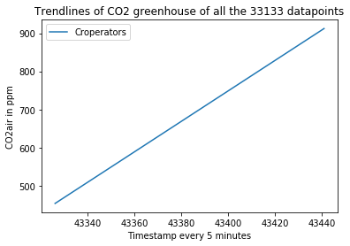

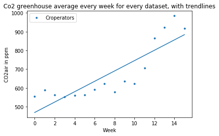